# Summarize

Avantika_Negi

2023-01-07

#delay of 12 mins, reduced evrything to one value

```r
summarize(flights, delay = mean(dep_delay, na.rm = TRUE))
```

```
## # A tibble: 1 × 1
##   delay
##   <dbl>
## 1  12.6
```

#freely omit NA values, departure column has NAs in it. We have to consider exactly what we want in this case

```r
summarize(flights, delay = mean(dep_delay))
```

```
## # A tibble: 1 × 1
##   delay
##   <dbl>
## 1    NA
```

#Going to group by the day of the year, we want to have the mean depaarture delay now.

```r
by_day <- group_by(flights, year, month, day)
summarize(by_day, delay = mean(dep_delay, na.rm = TRUE))
```

```
## # A tibble: 365 × 4
## # Groups:   year, month [12]
##     year month   day delay
##    <int> <int> <int> <dbl>
##  1  2013     1     1 11.5
##  2  2013     1     2 13.9
##  3  2013     1     3 11.0
##  4  2013     1     4  8.95
##  5  2013     1     5  5.73
##  6  2013     1     6  7.15
##  7  2013     1     7  5.42
##  8  2013     1     8  2.55
##  9  2013     1     9  2.28
## 10  2013     1    10  2.84
## # … with 355 more rows
```

#microplate reader readings for three technical replicates #specify each condition in the three columns, rows and group them by the exerimental condition

```r
summarize(flights, delay = n())  #mean(dep_delay, na.rm = TRUE))
```

```
## # A tibble: 1 × 1
##    delay
##    <int>
## 1 336776
```

# Find the realtionship between distance and average delay fro each destination

#group flights by destination

#summarize to compute distance, average delay and number of flgihts

# filter, to remove noisy points and Honululu airport

#Pipe operator, code reads easily

```r
delays <- flights %>%
  group_by(dest) %>%
  summarize(
    count = n(),
    dist = mean(distance, na.rm = TRUE),
    delay = mean(arr_delay, na.rm = TRUE)
  ) %>%
  filter(count > 20, dest != "HNL")
delays
```

```
## # A tibble: 96 × 4
##    dest  count  dist delay
##    <chr> <int> <dbl> <dbl>
##  1 ABQ     254 1826   4.38
##  2 ACK     265  199   4.85
##  3 ALB     439  143  14.4
##  4 ATL   17215  757. 11.3
##  5 AUS    2439 1514.  6.02
##  6 AVL     275  584.  8.00
##  7 BDL     443  116   7.05
##  8 BGR     375  378   8.03
##  9 BHM     297  866. 16.9
## 10 BNA    6333  758. 11.8
## # … with 86 more rows
```

#The grouping is by destination, not by yr, month. The summarize only gives the columns included in the three lines and the grouping variable (lose a lot of columns).

```r
delays <- flights %>%
  group_by(dest) %>%
  summarize(
    count = n(),
    dist = mean(distance, na.rm = TRUE),
    delay = mean(arr_delay, na.rm = TRUE),
    day = first(day)
  ) %>%
  filter(count > 20, dest != "HNL")
delays
```

```
## # A tibble: 96 × 5
##    dest  count  dist delay   day
##    <chr> <int> <dbl> <dbl> <int>
##  1 ABQ     254 1826   4.38     1
##  2 ACK     265  199   4.85     1
##  3 ALB     439  143  14.4      1
##  4 ATL   17215  757. 11.3      1
##  5 AUS    2439 1514.  6.02     1
##  6 AVL     275  584.  8.00     1
##  7 BDL     443  116   7.05     1
##  8 BGR     375  378   8.03     1
##  9 BHM     297  866. 16.9      2
## 10 BNA    6333  758. 11.8      1
## # … with 86 more rows
```

## When using a dataframe function na.rm in r refers to the logical parameter that tells the function whether or not to remove NA values from the calculation.

## It literally means NA remove. It is neither a function nor an operation. It is simply a parameter used by several dataframe functions. They include colSums(), rowSums(), colMeans() and rowMeans(). When na.rm is TRUE, the function skips over any NA values.

## However, when na.rm is FALSE, then it returns NA from the calculation being done on the entire row or column.

#Alternative to PIPE #filter(summarize(group_by(flights), dest), count = …), count > 20 …)

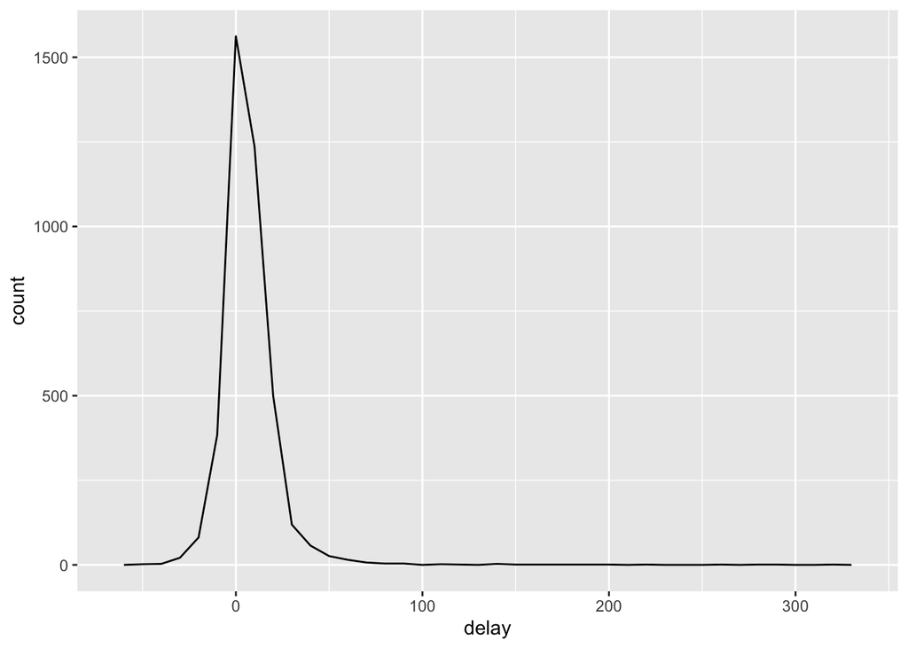

```r
#making another table
not_cancelled <- flights %>% filter(!is.na(dep_delay), !is.na(arr_delay))

delays <- not_cancelled %>%
  group_by(tailnum) %>%
  summarize(
    delay = mean(arr_delay)
  )

ggplot(data = delays, mapping = aes(x = delay)) +
  geom_freqpoly(binwidth = 10)
```

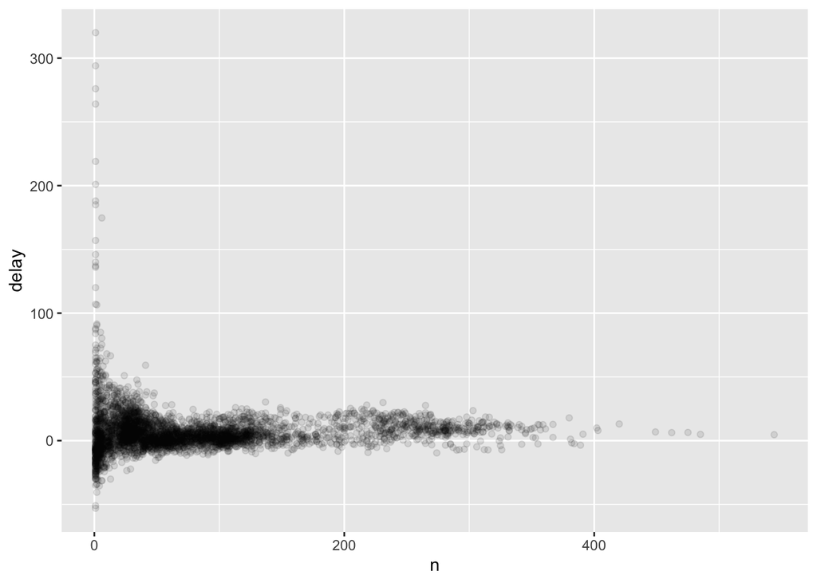

```r
not_cancelled <- flights %>% filter(!is.na(dep_delay), !is.na(arr_delay))

#writing a table into a ggplot!!!
p <- not_cancelled %>%
   group_by(tailnum) %>%
   summarize(
     delay = mean(arr_delay),
     n = n()
   ) %>%

   ggplot(mapping = aes(y = delay, x = n)) +
     geom_point(alpha = 1/10)
p
```

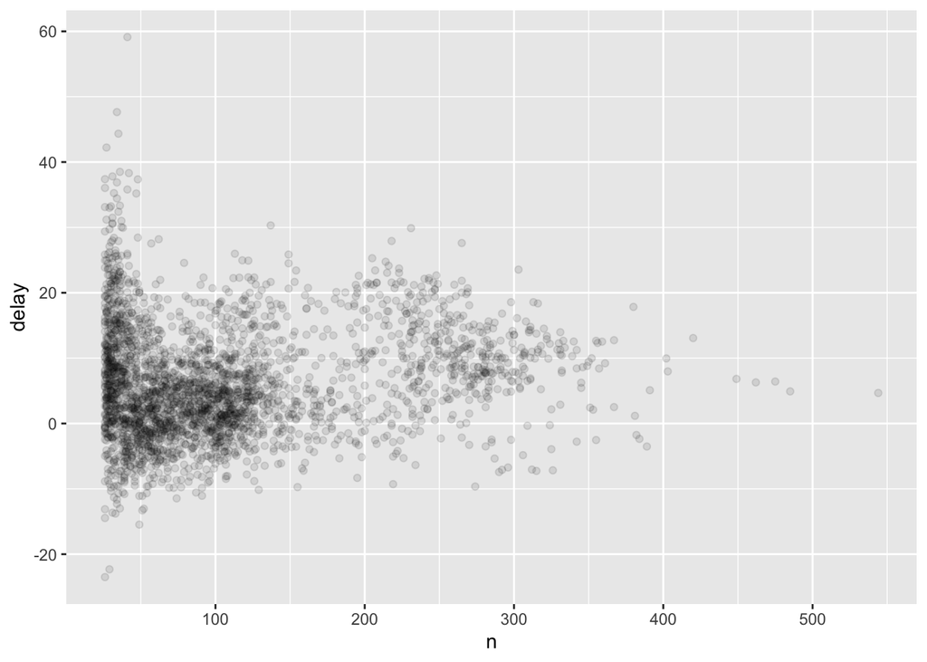

```r
not_cancelled <- flights %>% filter(!is.na(dep_delay), !is.na(arr_delay))

#writing a table into a ggplot!!!
p <- not_cancelled %>%
   group_by(tailnum) %>%
   summarize(
     delay = mean(arr_delay),
     n = n()
   ) %>%
   filter(n > 25) %>%
   ggplot(mapping = aes(y = delay, x = n)) +
     geom_point(alpha = 1/10)
p
```

#CHAPTER 7.3, 7.7

#Demo histograms

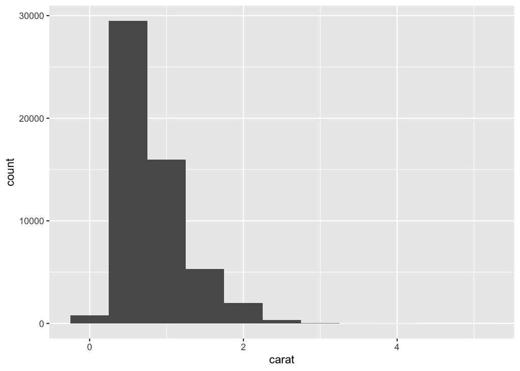

```r
ggplot(data = diamonds) +
  geom_histogram(mapping = aes(x = carat), binwidth = 0.5)
```

#way of looking at probability densities

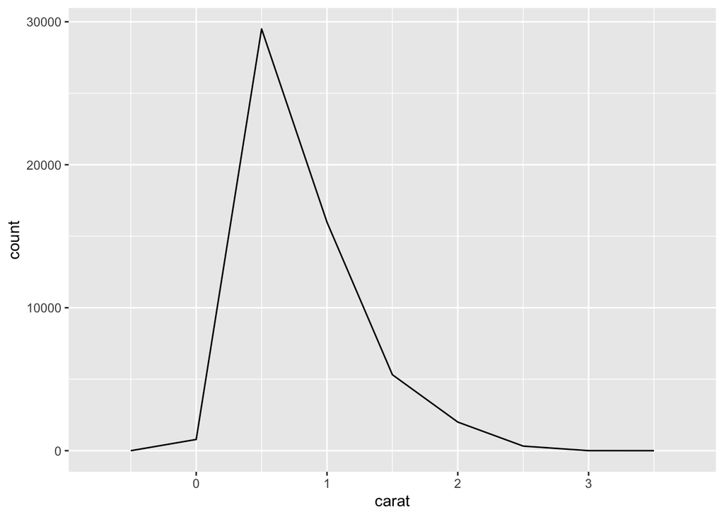

```r
diamonds %>%
  filter(carat < 3) %>%
  ggplot() +
  geom_freqpoly(mapping = aes(x = carat), binwidth = 0.5)
```

#Nice thing about freqpoly allows one to compare

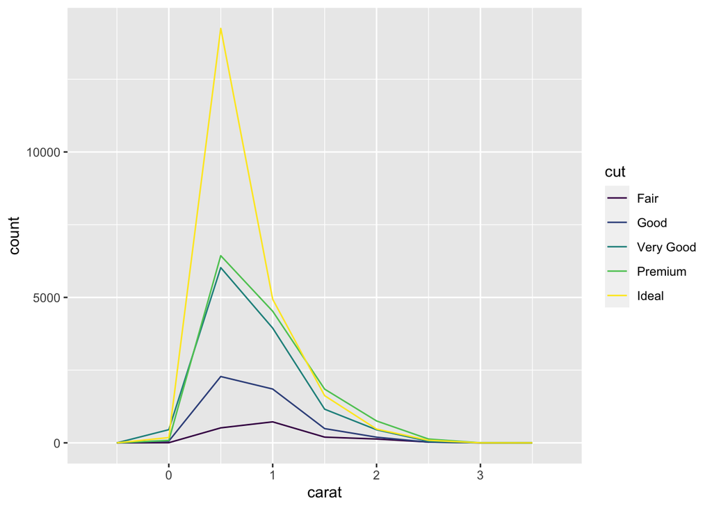

```r
diamonds %>%
  filter(carat < 3) %>%
  ggplot() +
  geom_freqpoly(mapping = aes(x = carat, color = cut), binwidth = 0.5)
```

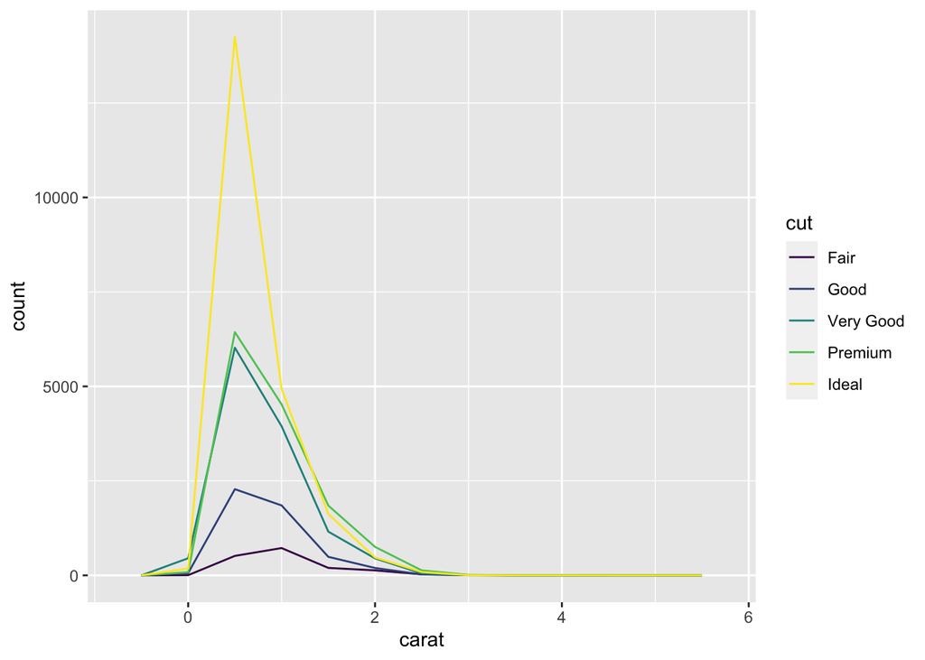

```r
  ggplot(diamonds) +
  geom_freqpoly(aes(carat, color = cut), binwidth = 0.5)
```